# Voter Prediction Model - Data Cleaning

Keyan Halperin

```r
#package to open .dta files
#install.packages('readstata13')
require(readstata13)

setwd('C:/Users/Keyan/Google Drive/Projects')
anes.data = read.dta13('anes_timeseries_cdf.dta', generate.factors = T, nonint.factors = T)
```

```r
names(anes.data)[2] = 'year'
summary(anes.data$year)
```

```
   Min. 1st Qu.  Median    Mean 3rd Qu.    Max.
   1948    1970    1984    1983    1998    2012
```

For the sake of simplicity, we will only look at presidential elections since 1996.

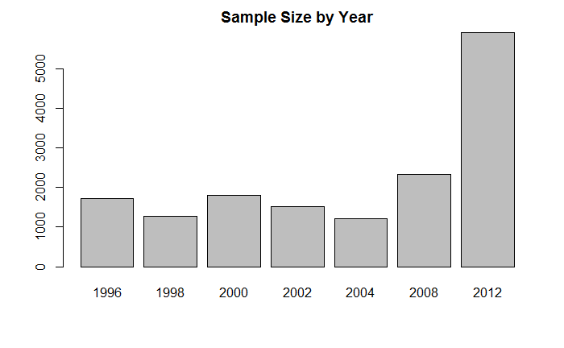

```r
plot(as.factor(anes.data$year[anes.data$year >= 1996]), main = 'Sample Size by Year')
```

```r
#Only include years of interest
anes.data = anes.data[anes.data$year == 1996 | anes.data$year == 2000 | anes.data$year == 2004 |
                      anes.data$year == 2008 | anes.data$year == 2012, ]
#A much easier way to write that
anes.data = anes.data[anes.data$year %in% seq(1996, 2012, 4),]
summary(anes.data$year)
```

```
   Min. 1st Qu.  Median    Mean 3rd Qu.    Max.
   1996    2000    2008    2007    2012    2012
```

```r
#Number of NAs
sum(is.na(anes.data))
```

```
[1] 7729302
```

There are over 7 million NAs, but there are even more missing values since not all missing values are coded as NA, so we’ll definitely have to do some data cleaning.

```r
#Data Dimensions
dim(anes.data) #Approximately 13,000 observations and 1,000 variables
```

```
[1] 12969   952
```

```r
#Summary of the first 20 variables
str(anes.data[,1:20])
```

```
'data.frame':   12969 obs. of  20 variables:
 $ Version : chr  "ANES_cdf-VERSION:2015-May-14" "ANES_cdf-VERSION:2015-May-14" "ANES_cdf-VERSION:2015-May-14" "ANES_cdf-VERSION:2015-May-14" ...
 $ year    : num  1996 1996 1996 1996 1996 ...
 $ VCF0006 : num  1001 1002 1003 1004 1005 ...
 $ VCF0006a: num  19942539 19920511 19921089 19942448 19920979 ...
 $ VCF0009x: num  0.83 0.504 0.557 1.681 0.567 ...
 $ VCF0010x: num  0.83 0.504 0.557 1.681 0.567 ...
 $ VCF0011x: num  0.83 0.504 0.557 1.681 0.567 ...
 $ VCF0009y: num  0.83 0.504 0.557 1.681 0.567 ...
 $ VCF0010y: num  0.83 0.504 0.557 1.681 0.567 ...
 $ VCF0011y: num  0.83 0.504 0.557 1.681 0.567 ...
 $ VCF0009z: num  0.83 0.504 0.557 1.681 0.567 ...
 $ VCF0010z: num  0.83 0.504 0.557 1.681 0.567 ...
 $ VCF0011z: num  0.83 0.504 0.557 1.681 0.567 ...
 $ VCF0012 : int  NA NA NA NA NA NA NA NA NA NA ...
 $ VCF0012a: int  0 1 1 0 0 2 1 3 3 3 ...
 $ VCF0012b: int  4 2 2 2 1 3 4 4 3 4 ...
 $ VCF0013 : Factor w/ 2 levels "0. No Post-election interview data",..: 2 2 2 2 2 2 2 2 2 2 ...
 $ VCF0014 : Factor w/ 2 levels "0. No Pre-election interview data present",..: 2 2 2 2 2 2 2 2 2 2 ...
 $ VCF0015a: Factor w/ 3 levels "0. Pre IW not abbreviated [1992:'Long' form Pre]",..: 1 1 1 1 1 1 1 1 1 1 ...
 $ VCF0015b: Factor w/ 3 levels "0. Post IW is not abbreviated",..: 1 1 1 1 1 1 1 1 1 1 ...
```

There are almost 1000 variables in the data, but we will only consider variables which are potentially related to how someone will vote and are feasible to be known or determined.

```r
variables = c('VCF0006a', 'year',   'VCF0013', 'VCF0017', 'VCF0101', 'VCF0102', 'VCF0104',
              'VCF0106', 'VCF0110', 'VCF0112', 'VCF0114', 'VCF0118', 'VCF0127', 'VCF0128',
              'VCF0138', 'VCF0143', 'VCF0146', 'VCF0147', 'VCF0721', 'VCF0901b', 'VCF0900c',
              'VCF0302', 'VCF0303', 'VCF0702', 'VCF0703', 'VCF0704a', 'VCF9027')
data = anes.data[variables]
#Change variable names
names(data) = c( 'id', 'year', 'post', 'method', 'age', 'age.group', 'gender', 'race', 'educ',
                 'region', 'income', 'work', 'union', 'religion', 'num.children', 'parents.native',
                 'home.own','marital.stat', 'donate', 'state', 'district', 'party.1', 'party.2',
                 'did.vote', 'reg.vote', 'pres.vote', 'previous.vote' )
str(data)
```

```
'data.frame':   12969 obs. of  27 variables:
 $ id            : num  19942539 19920511 19921089 19942448 19920979 ...
 $ year          : num  1996 1996 1996 1996 1996 ...
 $ post          : Factor w/ 2 levels "0. No Post-election interview data",..: 2 2 2 2 2 2 2 2 2 2 ...
 $ method        : Factor w/ 5 levels "0. All personal",..: 1 3 3 1 3 3 3 1 1 1 ...
 $ age           : Factor w/ 84 levels "00. NA; DK; RF; no Pre IW",..: 23 59 15 6 9 27 30 54 36 13 ...
 $ age.group     : Factor w/ 8 levels "0. NA; DK; RF; no Pre IW",..: 4 7 3 2 2 4 5 7 5 3 ...
 $ gender        : Factor w/ 3 levels "0. NA; no Pre IW",..: 3 3 2 2 3 2 2 2 3 2 ...
 $ race          : Factor w/ 5 levels "0. Missing, pre-1966 data",..: 4 2 4 4 2 2 2 2 2 2 ...
 $ educ          : Factor w/ 5 levels "0. DK; NA; no Pre IW; short-form 'new' Cross Section",..: 5 3 3 4 5 4 4 3 3 4 ...
 $ region        : Factor w/ 5 levels "0. NA (1948)",..: 5 5 4 4 5 3 3 3 3 3 ...
 $ income        : Factor w/ 6 levels "0. DK; NA; refused to answer; no Pre IW",..: 4 4 3 3 5 3 5 2 5 4 ...
 $ work          : Factor w/ 6 levels "1. Employed",..: 4 3 1 1 1 2 1 3 1 1 ...
 $ union         : Factor w/ 3 levels "0. DK; NA; no Pre IW; short-form 'new' Cross",..: 3 3 3 3 3 3 2 2 3 3 ...
 $ religion      : Factor w/ 5 levels "0. DK; NA; refused to answer; no Pre IW; no Post IW;",..: 2 2 2 2 3 2 2 5 2 2 ...
 $ num.children  : Factor w/ 10 levels "0. None","1. One",..: 10 10 10 10 10 10 10 10 10 10 ...
 $ parents.native: Factor w/ 4 levels "1. Yes","5. No",..: 1 1 2 2 1 1 1 1 1 1 ...
 $ home.own      : Factor w/ 4 levels "1. Yes, own",..: 1 2 1 2 2 1 1 1 1 1 ...
 $ marital.stat  : Factor w/ 8 levels "1. Married","2. Never married",..: 1 5 1 2 1 1 1 1 1 1 ...
 $ donate        : Factor w/ 3 levels "0. DK; NA; no Post IW; form III,IV (1972);",..: 2 2 2 2 2 2 2 2 2 2 ...
 $ state         : chr  "CO" "WA" "TX" "TX" ...
 $ district      : chr  "CO06" "WA02" "TX15" "TX15" ...
 $ party.1       : Factor w/ 7 levels "1. Republican",..: 2 2 5 5 2 3 1 5 2 1 ...
 $ party.2       : Factor w/ 4 levels "0. DK; NA; other; refused to answer; no Pre IW",..: 3 2 2 2 3 3 4 2 2 4 ...
 $ did.vote      : Factor w/ 3 levels "0. DK; NA; no Post IW; refused to say if voted;",..: 3 3 2 3 3 2 3 3 3 3 ...
 $ reg.vote      : Factor w/ 4 levels "0. DK/NA if voted; DK/NA whether registered (includes",..: 4 4 2 4 4 2 4 4 4 4 ...
 $ pres.vote     : Factor w/ 3 levels "0. Did not vote; DK/NA if voted; refused to say if",..: 1 2 1 2 3 1 3 2 2 1 ...
 $ previous.vote : Factor w/ 6 levels "0. R did not vote in previous election; R has never voted",..: 2 2 1 2 2 1 3 2 3 1 ...
```

We will now go through each variable to see if there is anything that needs to be changed or cleaned.

```r
#ID
summary(data$id)
```

```
    Min.  1st Qu.   Median     Mean  3rd Qu.     Max.
19920000 20000000 20080000 20070000 20120000 20130000
```

```r
#Check to make sure there are no duplicates
length(data$id) == length(unique(data$id)) #Looks good
```

```
[1] TRUE
```

```r
#Post-election Interview Data
summary(data$post)
```

```
     0. No Post-election interview data 1. Post-election interview data present
                                   1202                                   11767
```

```r
#Drop individuals for whom we do not know how they voted
data = data[data$post != '0. No Post-election interview data', ]
```

```r
#Survey Method
summary(data$method)
```

```
                            0. All personal 1. Telephone pre (personal post or no post)
                                       6572                                           0
           2. Telephone post (personal pre)                            3. All telephone
                                        865                                         749
       4. All internet (2012: pre and post)
                                       3581
```

Also, we will recode missing values as NA since that is how missing values should be represented in R. Note that DK stands for ‘Don’t Know’, RF means that they refused to respond.

```r
#Age
head(summary(data$age), 10)
```

```
00. NA; DK; RF; no Pre IW                        17                        18                        19
                      104                         2                        84                       118
                       20                        21                        22                        23
                      155                       130                       150                       164
                       24                        25
                      171                       185
```

```r
tail(summary(data$age), 10)
```

```
                                                     90                                                      91
                                                     20                                                       8
                                                     92                                                      93
                                                      2                                                       4
                                                     94                                                      95
                                                      0                                                       0
                                                     96 97. 97 years old (1952, 1974, 1996 and later: or older)
                                                      1                                                       0
     98. 98 years old (1958-1962, 1966, 1968: or older)        99. 99 years old (1976-1990,1994,2002: or older)
                                                      0                                                       0
```

```r
#Recode missing values as NA
data$age[data$age == '00. NA; DK; RF; no Pre IW'] <- NA
data$age = as.numeric(as.character(data$age))
summary(data$age) #Looks good
```

```
   Min. 1st Qu.  Median    Mean 3rd Qu.    Max.    NA's
  17.00   35.00   48.00   48.56   61.00   96.00     104
```

```r
#Age Group
summary(data$age.group)
```

```
         0. NA; DK; RF; no Pre IW                        1. 17 - 24                        2. 25 - 34
                              104                               974                              1909
                       3. 35 - 44                        4. 45 - 54                        5. 55 - 64
                             2119                              2207                              2152
                       6. 65 - 74 7. 75 - 99 and over (except 1954)
                             1472                               830
```

```r
data$age.group[data$age.group == '0. NA; DK; RF; no Pre IW'] <- NA
```

```r
#Gender
summary(data$gender) #Looks good
```

```
0. NA; no Pre IW          1. Male        2. Female
               0             5447             6320
```

```r
#Race
summary(data$race)
```

```
0. Missing, pre-1966 data     1. White non-Hispanic     2. Black non-Hispanic                  3. Other
                        0                      7492                      1932                      2266
    9. Missing, DK/REF/NA
                       77
```

```r
data$race[data$race == '9. Missing, DK/REF/NA'] <- NA
```

```r
#Education
summary(data$educ)
```

```
 0. DK; NA; no Pre IW; short-form 'new' Cross Section                  1. Grade school or less (0-8 grades)
                                                   79                                                   351
2. High school (12 grades or fewer, incl. non-college     3. Some college (13 grades or more but no degree;
                                                 4215                                                  3708
        4. College or advanced degree (no cases 1948)
                                                 3414
```

Remember that each level of a factor variable is also stored as an integer. So instead of typing out the name of the level e.g. ‘0. DK; NA; no Pre IW; short-form ’new’ Cross Section’, you can simply refer to the integer that the level corresponds to. For example:

```r
data$educ[as.numeric(data$educ) == 1] <- NA
```

Although it is easier to type, it is not as clear to the reader what exactly is being done.

Also, there does not appear to be a clear, systematic way to recode these values as NA since sometimes they are not conistently labled.

```r
#Region of Residence
summary(data$region) #Looks good
```

```
                                            0. NA (1948)        1. Northeast (CT, ME, MA, NH, NJ, NY, PA, RI, VT)
                                                       0                                                     1819
   2. North Central (IL, IN, IA, KS, MI, MN, MO, NE, ND,   3. South (AL, AR, DE, D.C., FL, GA, KY, LA, MD, MS, NC
                                                    2637                                                     4610
4. West (AK, AZ, CA, CO, HI, ID, MT, NV, NM, OR, UT, WA,
                                                    2701
```

```r
#Household Income
summary(data$income)
```

```
0. DK; NA; refused to answer; no Pre IW                   1. 0 to 16 percentile                  2. 17 to 33 percentile
                                    814                                    2017                                    1959
                 3. 34 to 67 percentile                  4. 68 to 95 percentile                 5. 96 to 100 percentile
                                   3871                                    2547                                     559
```

```r
data$income[data$income == '0. DK; NA; refused to answer; no Pre IW'] <- NA
```

```r
#Employmeny Status
summary(data$work)
```

```
                                             1. Employed        2. Not employed: laid off, unemployed, on strike,
                                                    6751                                                     1396
                                              3. Retired 4. Homemaker (since 1972: not working 20 or more hrs/wk;
                                                    2374                                                      815
  5. Student (since 1972: not working 20 or more hrs/wk;                                     9. DK; NA; no Pre IW
                                                     412                                                       19
```

```r
data$work[data$work == '9. DK; NA; no Pre IW'] <- NA
```

```r
#Union Membership
summary(data$union)
```

```
          0. DK; NA; no Pre IW; short-form 'new' Cross 1. Yes, someone (1948: head) in household belongs to a
                                                    52                                                   1788
   2. No, no one in household belongs to a labor union
                                                  9927
```

```r
data$union[as.numeric(data$union) == 1] <- NA
```

```r
#Religion
summary(data$religion)
```

```
0. DK; NA; refused to answer; no Pre IW; no Post IW;                                        1. Protestant
                                                 141                                                 5457
                        2. Catholic [Roman Catholic]                                            3. Jewish
                                                2791                                                  222
     4. Other and none (also includes DK preference)
                                                3156
```

```r
data$religion[data$union == '0. DK; NA; refused to answer; no Pre IW; no Post IW;'] <- NA
```

```r
#Number of Children
summary(data$num.children)
```

```
                                 0. None                                   1. One                                   2. Two
                                    6036                                     1216                                     1055
                                3. Three                                  4. Four                                  5. Five
                                     698                                        0                                        0
                                  6. Six                                 7. Seven                         8. Eight or more
                                       0                                        0                                        0
9. NA; no Pre IW; Panel (1992,1996,2002)                                     NA's
                                    1207                                     1555
```

Number of children is coded as a categorical variable instead of a numeric one. One way to convert this into a numeric variable would be:

```r
data$num.children2[data$num.children == '0. None'] <- 0
data$num.children2[data$num.children == '1. One'] <- 1
data$num.children2[data$num.children == '2. Two'] <- 2
data$num.children2[data$num.children == '3. Three'] <- 3
```

However, since each level of a factor variable is stored as an integer, a much easier way to do this would be:

```r
data$num.children = as.numeric(data$num.children) - 1
data$num.children[data$num.children == 9] <- NA
summary(data$num.children) #Looks good!
```

```
   Min. 1st Qu.  Median    Mean 3rd Qu.    Max.    NA's
 0.0000  0.0000  0.0000  0.6019  1.0000  3.0000    2762
```

Create a new indicator variable of whether or not the individual has children where ‘Yes’ = Has at least one child, ‘No’ = Does not have any children.

```r
#Children Indicator
data$children.ind = ifelse(data$num.children >= 1, 'Yes', 'No')
data$children.ind = as.factor(data$children.ind)
summary(data$children.ind)
```

```
  No  Yes NA's
6036 2969 2762
```

```r
#Native Parents
summary(data$parents.native)
```

```
                                              1. Yes                                                5. No
                                                9722                                                 2009
                                               8. DK 9. NA; RF; no Pre IW; short-form 'new' Cross Section
                                                  16                                                   20
```

```r
#Recode levels 3 and 4 as NA
data$parents.native[as.numeric(data$parents.native) >= 3] <- NA
```

```r
#Home Ownership
summary(data$home.own)
```

```
                            1. Yes, own                        2. No, not owned                                   8. DK
                                   7803                                    3921                                       8
9. NA; RF; no Pre IW; short form (1992)
                                     35
```

```r
data$home.own[as.numeric(data$home.own) >= 3] <- NA
```

```r
#Marital Status
summary(data$marital.stat)
```

```
                                                                                                      1. Married
                                                                                                            5826
                                                                                                2. Never married
                                                                                                            2276
                                                                                                     3. Divorced
                                                                                                            1564
                                                                                                    4. Separated
                                                                                                             360
                                                                                                      5. Widowed
                                                                                                            1131
                                                          7. Partners; not married (VOLUNTEERED [exc.1986,2012])
                                                                                                             577
8. R not married/partnered, refused to say whether never married, divorced, separated or widowed (1992 only); DK
                                                                                                               2
                   9.  NA; no Pre IW; unmarried at time of IW (1952 only); short-form 'new' Cross-Section (1992)
                                                                                                              31
```

```r
data$marital.stat[as.numeric(data$marital.stat) >= 7] <- NA
```

```r
#Campaign Donations
summary(data$donate)
```

```
         0. DK; NA; no Post IW; form III,IV (1972); 1. No (includes 'not asked for money' in 1966,1968)
                                                  5                                               10355
          2. Yes (includes 'tax check-off' in 1976)
                                               1407
```

```r
data$donate[data$donate == '0. DK; NA; no Post IW; form III,IV (1972);'] <- NA
```

```r
#State of Residence
data$state = as.factor(data$state)
summary(data$state)
```

```
  99   AK   AL   AR   AZ   CA   CO   CT   DC   DE   FL   GA   HI   IA   ID   IL   IN   KS   KY   LA   MA   MD   ME   MI   MN
   2    3  243  110  224 1344  262  118   28   47  746  337    7  129   18  372  307   81   87  280  278  177   15  467  290
  MO   MS   MT   NC   ND   NE   NH   NJ   NM   NV   NY   OH   OK   OR   PA   RI   SC   SD   TN   TX   UT   VA   VT   WA   WI
 159   98   23  310   52   56   60  267  130   90  639  419  103  198  389   43  181   16  273 1133  116  407    8  266  289
  WV   WY
  50   20
```

```r
data$state[data$state == '99'] <- NA
```

```r
#District of Residence
data$district = as.factor(data$district)
summary(data$district)
```

```
   9999    VA09    MN01    CA04    WI04    LA04    MI05    OR04    TX16    CA19    IN02    IN06    NJ02    AR04    MI04
    186     125     124     117     105     103     100      96      96      91      84      82      79      75      74
   AL07    TX27    TN02    FL04    CO02    TX29    OH04    MA03    PA01    FL05    NM02    FL12    GA01    TX28    TX15
     73      73      72      71      69      69      68      67      67      66      66      64      64      63      61
   TX21    CA40    IL07    LA02    SC01    WA07    TX11    AL06    CO01    FL02    TN07    CA11    FL06    GA02    TX20
     61      60      60      60      59      59      58      56      55      54      53      52      52      52      52
   UT02    CA08    GA06    LA05    ND01    CA20    TX08    VA03    CO04    DE01    MS03    NY27    WA09    AZ03    CT03
     52      51      51      51      51      50      48      47      46      46      46      46      46      45      45
   OK05    TX30    VA07    AZ05    CA42    CO07    IA04    NM01    WI05    FL27    KS04    OH08    AL03    MN05    NC12
     45      45      45      44      44      44      44      44      44      43      43      43      42      42      42
   TX17    FL09    NC01    NY19    SC06    MA01    NV02    VA05    AZ06    MA08    MD08    MN04    NC04    OR05    PA09
     42      41      41      41      41      40      40      40      39      39      39      39      39      39      39
   IA03    NJ11    NY21    OH18    TN09    VA08    IL01    IL02    NJ10 (Other)
     38      38      38      38      38      37      36      36      36    6065
```

```r
data$district[data$district == '9999'] <- NA
```

```r
#Political Party 1
summary(data$party.1)
```

```
                  1. Republican                  2. Independent 3. No preference; none; neither
                           2847                            3521                             506
                       4. Other                     5. Democrat                           8. DK
                            215                            4545                              73
                 9. NA; refused
                             60
```

```r
data$party.1[as.numeric(data$party.1) >= 6] <- NA
```

```r
#Political Party 2
summary(data$party.2)
```

```
0. DK; NA; other; refused to answer; no Pre IW               1. Democrats (including leaners)
                                            90                                           6179
                               2. Independents             3. Republicans (including leaners)
                                          1400                                           4098
```

```r
data$party.2[data$party.2 == '0. DK; NA; other; refused to answer; no Pre IW'] <- NA
```

```r
#Voted in Election
summary(data$did.vote)
```

```
0. DK; NA; no Post IW; refused to say if voted;                             1. No, did not vote
                                             23                                            2565
                                  2. Yes, voted
                                           9179
```

```r
data$did.vote[data$did.vote == '0. DK; NA; no Post IW; refused to say if voted;'] <- NA
```

```r
#Registered
summary(data$reg.vote)
```

```
0. DK/NA if voted; DK/NA whether registered (includes                   1. Not registered, and did not vote
                                                   34                                                  1279
                      2. Registered, but did not vote                                 3. Voted (registered)
                                                 1275                                                  9179
```

```r
data$reg.vote[data$reg.vote == '0. DK/NA if voted; DK/NA whether registered (includes'] <- NA
```

```r
#Registered Indicator
#Create indicator variable of whether or not someone is registered to vote
data$registered = ifelse(data$reg.vote == "2. Registered, but did not vote"|
                         data$reg.vote == "3. Voted (registered)",
                         "Yes", "No")
data$registered = as.factor(data$registered)
summary(data$registered)
```

```
   No   Yes  NA's
 1279 10454    34
```

```r
#Presidential Vote
summary(data$pres.vote)
```

```
0. Did not vote; DK/NA if voted; refused to say if                                        1. Democrat
                                              3094                                               5100
                                     2. Republican
                                              3573
```

```r
#Presidential Vote Indicator
#Create indicator variable of whether or not someone voted for president
data = data[!is.na(data$did.vote), ]
data$did.vote.pres = ifelse(data$pres.vote == '0. Did not vote; DK/NA if voted; refused to say if',
                            'Did not vote for president', 'Voted for president')
data$did.vote.pres = as.factor(data$did.vote.pres)
summary(data$did.vote.pres)
```

```
Did not vote for president        Voted for president
                      3071                       8673
```

```r
#Previous Vote
summary(data$previous.vote)
```

```
0. R did not vote in previous election; R has never voted                      1. Voted: Democratic Pres. Candidate
                                                     1821                                                      2112
                     2. Voted: Republican Pres. Candidate             3. Voted: DK/NA/Refused which Pres. Candidate
                                                     1762                                                        95
                                5. Voted: Other candidate 9. DK/NA/refused to say if voted in previous presidential
                                                      398                                                        68
                                                     NA's
                                                     5488
```

```r
data$previous.vote[data$previous.vote == '9. DK/NA/refused to say if voted in previous presidential'] <- NA
#Previous Vote Indicator
#Create indicator variable of whether or not someone voted for president in the previous election
data$previous.did.vote = ifelse(data$previous.vote == '0. R did not vote in previous election; R has never voted',
                                'Did not vote', 'Voted')
data$previous.did.vote = as.factor(data$previous.did.vote)
summary(data$previous.did.vote)
```

```
Did not vote        Voted         NA's
        1821         4367         5556
```

```r
#Previous Vote Candidate
#Create variable for who someone voted for president in the previous election
data$previous.pres.vote = ifelse(data$previous.vote == '1. Voted: Democratic Pres. Candidate', 'Dem',
                                 ifelse(data$previous.vote == '2. Voted: Republican Pres. Candidate', 'Rep', NA))
data$previous.pres.vote = as.factor(data$previous.pres.vote)
summary(data$previous.pres.vote)
```

```
 Dem  Rep NA's
2112 1762 7870
```

```r
#Home Ownership
summary(data$home.own)
```

```
                            1. Yes, own                        2. No, not owned                                   8. DK
                                   7796                                    3906                                       0
9. NA; RF; no Pre IW; short form (1992)                                    NA's
                                      0                                      42
```

```r
#As you can see in the summary of home.own, there are multiple unused levels (i.e. frequency = 0)
#Fortunately, there is an easy function that drops all unused levels
data = droplevels(data)
#Final Data Summary
summary(data)
```

```
       id                year                                           post                                        method
 Min.   :19920002   Min.   :1996   1. Post-election interview data present:11744   0. All personal                     :6558
 1st Qu.:20001622   1st Qu.:2000                                                   2. Telephone post (personal pre)    : 865
 Median :20081902   Median :2008                                                   3. All telephone                    : 748
 Mean   :20068135   Mean   :2007                                                   4. All internet (2012: pre and post):3573
 3rd Qu.:20123685   3rd Qu.:2012
 Max.   :20126864   Max.   :2012

      age             age.group          gender                        race
 Min.   :17.00   4. 45 - 54:2202   1. Male  :5436   1. White non-Hispanic:7482
 1st Qu.:35.00   5. 55 - 64:2150   2. Female:6308   2. Black non-Hispanic:1928
 Median :48.00   3. 35 - 44:2116                    3. Other             :2258
 Mean   :48.57   2. 25 - 34:1901                    NA's                 :  76
 3rd Qu.:61.00   6. 65 - 74:1472
 Max.   :96.00   (Other)   :1800
 NA's   :103     NA's      : 103
                                                    educ                                                           region
 1. Grade school or less (0-8 grades)                 : 351   1. Northeast (CT, ME, MA, NH, NJ, NY, PA, RI, VT)       :1814
 2. High school (12 grades or fewer, incl. non-college:4200   2. North Central (IL, IN, IA, KS, MI, MN, MO, NE, ND,   :2633
 3. Some college (13 grades or more but no degree;    :3704   3. South (AL, AR, DE, D.C., FL, GA, KY, LA, MD, MS, NC  :4603
 4. College or advanced degree (no cases 1948)        :3410   4. West (AK, AZ, CA, CO, HI, ID, MT, NV, NM, OR, UT, WA,:2694
 NA's                                                 :  79


                     income                                                           work
 1. 0 to 16 percentile  :2012   1. Employed                                             :6741
 2. 17 to 33 percentile :1954   2. Not employed: laid off, unemployed, on strike,       :1391
 3. 34 to 67 percentile :3868   3. Retired                                              :2371
 4. 68 to 95 percentile :2547   4. Homemaker (since 1972: not working 20 or more hrs/wk;: 811
 5. 96 to 100 percentile: 559   5. Student (since 1972: not working 20 or more hrs/wk;  : 411
 NA's                   : 804   NA's                                                    :  19

                                                    union                                                      religion
 1. Yes, someone (1948: head) in household belongs to a:1787   0. DK; NA; refused to answer; no Pre IW; no Post IW;: 138
 2. No, no one in household belongs to a labor union   :9907   1. Protestant                                       :5451
 NA's                                                  :  50   2. Catholic [Roman Catholic]                        :2788
                                                               3. Jewish                                           : 221
                                                               4. Other and none (also includes DK preference)     :3146


```

[output cut: 29 more lines]

```



                                                   previous.vote  children.ind registered                      did.vote.pres
 0. R did not vote in previous election; R has never voted:1821   No  :6024    No  : 1279   Did not vote for president:3071
 1. Voted: Democratic Pres. Candidate                     :2112   Yes :2959    Yes :10448   Voted for president       :8673
 2. Voted: Republican Pres. Candidate                     :1762   NA's:2761    NA's:   17
 3. Voted: DK/NA/Refused which Pres. Candidate            :  95
 5. Voted: Other candidate                                : 398
 NA's                                                     :5556

    previous.did.vote previous.pres.vote
 Did not vote:1821    Dem :2112
 Voted       :4367    Rep :1762
 NA's        :5556    NA's:7870
```

```r
write.csv(data, "ANES Final Data.csv", row.names = F)
```